# StatComp21003 homework

Hangjun Guo

2021-12-20

## A-21003-2021-09-23

## Question

Exercises 3.4, 3.11, and 3.20 (pages 94-96, Statistical Computing with R).

## Answer

**3.4**

算法原理：注意到若$Y \sim \operatorname{Exp}(1)$，令$X = \sqrt{2 \sigma^2 Y}$，则随机变量$X$的密度函数为
$$f(x)=\left(\frac{x^2}{2 \sigma^{2}}\right)^{'} e^{-x^{2} /\left(2 \sigma^{2}\right)}=
\frac{x}{\sigma^{2}} e^{-x^{2} /\left(2 \sigma^{2}\right)},$$
其中$x \geq 0, \sigma>0$，从而得到$f(x)$为Rayleigh分布密度函数。因此可以通过指数随机变量$Y$生成Rayleigh随机变量$X$。 对不同参数$\sigma=1, 2, 3, 4, 5$生成$\operatorname{Rayleigh}(\sigma)$分布随机数的R代码如下所示：

```r
library(knitr)#加载knitr package

#生成Rayleigh分布随机数
rrayleigh = function (size, sigma) {
  stopifnot(sigma > 0)#参数sigma>0
  u <-  runif(size)#均匀分布随机数
  sqrt(-2*sigma^2*log(u))#通过指数随机数生成Rayleigh随机数，其中-log(u)为指数随机数
}

#Rayleigh分布密度函数
drayleigh = function (x, sigma) {
  stopifnot(sigma > 0)#参数sigma>0
  y <-  x / (sigma^2) * exp(- x^2 / (2 * sigma^2))#Rayleigh分布密度函数
  y[x < 0] <-  0#x<0时密度为0
  y
}

#对不同的sigma=1, 2, 3, 4, 5分别生成Rayleigh随机数
size <- 1500#样本量
sigmas <- c(1, 2, 3, 4, 5)#参数sigma取值
samples <- sapply(sigmas, function(x) rrayleigh(size, x))#利用sapply对不同sigma生成Rayleigh随机数
samples <- data.frame(samples)#转为数据框
dimnames(samples)[[2]] <- paste("sigma =", sigmas)#重命名各列
kable(head(samples), caption = "表1.1：sigma=1, 2, 3, 4, 5时生成的Rayleigh随机数")#绘制数据样本表格
```

表1.1：sigma=1, 2, 3, 4, 5时生成的Rayleigh随机数

| sigma = 1 | sigma = 2 | sigma = 3 | sigma = 4 | sigma = 5 |
| --- | --- | --- | --- | --- |
| 1.2455407 | 4.527686 | 4.323562 | 2.067590 | 5.5158294 |
| 2.0534550 | 4.122368 | 3.616558 | 5.920237 | 6.3764597 |
| 0.5504207 | 2.283062 | 5.324225 | 1.836361 | 9.4693169 |
| 0.9339269 | 3.209739 | 4.116779 | 5.522364 | 0.3774525 |
| 0.3006245 | 5.077264 | 4.099802 | 8.576545 | 3.9060723 |
| 0.7128284 | 4.015494 | 7.322059 | 3.710527 | 8.1596671 |

**3.11**

首先生成1000个由两个正态随机变量$X_1 \sim N(0, 1)$和$X_2 \sim N(3, 1)$组成的复合分布随机数$X$。算法原理为先生成随机数$X_1$和$X_2$，则以概率$p_1$取值$X_1$，以概率$p_2$取值$X_2$即可得到复合分布随机数$X$。R代码如下所示：

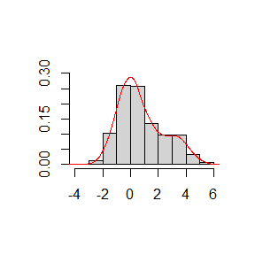

图2.1：p1=0.75时复合分布的样本直方图和密度曲线

```r
#生成复合分布随机数
rmix = function(size, p){
  x1 <- rnorm(size, 0, 1)#生成x1
  x2 <- rnorm(size, 3, 1)#生成x2
  u <- runif(size)#生成均匀分布随机数
  t <- as.integer(u<p)#t以概率p取1，以概率1-p取0
  x <- t*x1 + (1-t)*x2#生成复合分布随机数x
}

n <- 1000#样本量1000
p1 <- 0.75#p1取0.75
x <- rmix(n, p1)#生成1000个复合分布随机数

#绘制直方图和密度曲线
hist(x, freq = F, ylim=c(0, 0.3), main="", xlab="", ylab="")
lines(density(x), col="red")
```

由图2.1可以看到，当$p_1=0.75$时上述复合分布的经验密度曲线略有双峰性，在$x=0$附近峰度较大，在$x=3$附近峰度较小。

```r
# par(mfrow = c(3,3))#以下生成3*3图形矩阵
#
# for(p1 in seq(0.1, 0.9, 0.1)){
#   x <- rmix(n, p1)#对不同p1生成复合分布随机数
#   #绘制直方图和密度曲线
#   hist(x, freq = F, xlim=c(-6, 6), ylim=c(0, 0.4), main=paste("p1 = ", p1), xlab="", ylab="")
#   lines(density(x), col="red")
# }
```

**3.20**

由题意知，复合泊松过程$X(t)=\sum_{i=1}^{N(t)} Y_{i}, t \geq 0$，其中$\{N(t), t \geq 0\}$是参数为$\lambda$的泊松过程，$Y_1, Y_2, ...$独立同分布并且与$\{N(t), t \geq 0\}$相互独立。当$Y$服从伽玛分布时，$X(t)$为复合泊松-伽玛过程。模拟该过程的具体R代码如下所示：

```r
#泊松过程参数lambda, t；Gamma分布参数shape, scale
#生成复合泊松-伽玛过程的算法
PoiGammaProc = function(lambda, t, shape, scale){
  Tn <- rexp(1000, lambda)#不知道需要多少Tn，因此生成充分多的Tn。Tn为泊松过程的间隔时间服从指数分布
  Sn <- cumsum(Tn)#计算泊松过程到达时间
  n <- min(which(Sn > t)) - 1#[0, t]内的到达次数即为泊松过程随机数
  Y <- rgamma(n, shape = shape, scale = 1/scale)#生成N(t)个iid伽玛随机数Gamma(shape, scale)
  X <- sum(Y)#对N(t)个iid伽玛随机数求和，得到复合泊松-伽玛过程随机数
}
```

下面选择不同参数分别生成复合泊松-伽玛过程$X(10)$，计算所生成样本的期望和方差，并与理论值进行对比。

- 参数选择：取伽玛随机变量$Y \sim \operatorname{Gamma}(\alpha, \beta)$的形状参数$\alpha=4$和尺度参数$\beta=2$，变化泊松过程强度参数$\lambda={1, 2, 3}$。
- 复合泊松-伽玛过程$X(t)=\sum_{i=1}^{N(t)} Y_{i}$的期望$E[X(t)]=\lambda t E[Y_{1}]$，方差$Var[X(t)]=\lambda t E[Y_{1}^{2}]$。证明如下： 令$E[Y_1]=\mu$， $Var(Y_1)=\sigma^2$，通过对$N(t)$取条件期望可以得到，
  $$E[X(t)]=E[E[\sum_{i=1}^{n} Y_{i} \mid N(t)=n]]=E[N(t) \mu]=\lambda t \cdot \mu=\lambda t E\left[Y_{1}\right]$$
  $$\begin{aligned}
  \operatorname{Var}[X(t)] &=\operatorname{Var}\left[E\left[\sum_{i=1}^{n} Y_{i} \mid N(t)=n\right]\right]+E\left[\operatorname{Var}\left[\sum_{i=1}^{n} Y_{i} \mid N(t)=n\right]\right] \\
  &=\operatorname{Var}[N(t) \mu]+E\left[N(t)\sigma^2\right]=\mu^{2} \operatorname{Var}[N(t)]+\sigma^2 E[N(t)] \\
  &=\mu^{2} \lambda t+\sigma^2 \lambda t=\lambda t E\left[Y_{1}^{2}\right]
  \end{aligned}$$

代入伽玛分布期望和方差进一步可得，$E[X(t)]= \frac{\lambda t\alpha}{\beta}$，$Var[X(t)]=\frac{\lambda t(\alpha^2+\alpha)}{\beta^2}$。

```r
t <- 10#取t=10
lambda <- c(1:3)#变化泊松过程强度参数lambda=1,2,3
shape <- 4#伽玛分布形状参数取4
scale <- 2#伽玛分布尺度参数取2
size <- 1000#样本量为1000
#对不同参数lambda分别生成复合泊松-伽玛过程
Xt1 <- replicate(size, PoiGammaProc(lambda[1], t, shape, scale))#lambda=1
Xt2 <- replicate(size, PoiGammaProc(lambda[2], t, shape, scale))#lambda=2
Xt3 <- replicate(size, PoiGammaProc(lambda[3], t, shape, scale))#lambda=3
mat <- cbind(Xt1, Xt2, Xt3)#将三组样本合并为样本矩阵

#均值的对比
mean.s <- apply(mat, 2, mean, trim=.5)#利用apply函数计算模拟样本均值
mean.th <- sapply(lambda, function(x){
  x*t*shape/scale
})#计算理论复合泊松-伽玛过程的均值
mean.mat <- rbind(mean.s, mean.th)
kable(mean.mat, caption = "表3.1：复合泊松-伽玛过程模拟样本均值和理论均值对比，变化泊松过程强度参数lambda=1, 2, 3")
```

|  | Xt1 | Xt2 | Xt3 |
| --- | --- | --- | --- |
| mean.s | 19.6975 | 39.61647 | 59.52406 |
| mean.th | 20.0000 | 40.00000 | 60.00000 |

```r
#方差的对比
var.s <- (1-1/size)*apply(mat, 2, var)#利用apply函数计算模拟样本方差
var.th <- sapply(lambda, function(x){
  x*t*(shape^2+shape)/scale^2
})#计算理论复合泊松-伽玛过程的方差
var.mat <- rbind(var.s, var.th)
kable(var.mat, caption = "表3.2：复合泊松-伽玛过程模拟样本方差和理论方差对比，变化泊松过程强度参数lambda=1, 2, 3")
```

表3.2：复合泊松-伽玛过程模拟样本方差和理论方差对比，变化泊松过程强度参数lambda=1, 2, 3

|  | Xt1 | Xt2 | Xt3 |
| --- | --- | --- | --- |
| var.s | 50.22742 | 103.1684 | 147.1926 |
| var.th | 50.00000 | 100.0000 | 150.0000 |

由表3.1和表3.2可以看到，通过上述方法模拟得到的复合泊松-伽玛过程$X(10)$的均值和方差，都与理论计算得到的均值和方差非常接近，从而验证了利用上述算法生成复合泊松-伽玛过程的有效性。

## A-21003-2021-09-30

## Question

Exercises 5.4, 5.9, 5.13 and 5.14 (pages 149-151, Statistical Computing with R).

## Answer

**5.4**

算法原理：注意到若随机变量$X \sim \operatorname{Beta}(3, 3)$，则$X$的分布函数(cdf)为$F(x)=\int_{0}^{x} 30 t^{2}(1-t)^{2} \mathrm{~d} t$。利用Monte Carlo方法近似计算这一分布函数的R代码如下所示

```r
#利用MC方法近似计算Beta分布函数
cdfBeta <- function(x, alpha=3, beta=3, n=10000){ #x为需计算的点，alpha, beta为Beta分布参数，n为MC方法模拟次数
  stopifnot(x>0 && x<1)#排除定义域(0, 1)外的取值
  u <- runif(n, 0, x)#10000个[0,x]上的均匀分布随机数
  g <- (1/beta(alpha, beta)) * u^(alpha-1) * (1-u)^(beta-1)#计算g(x)
  cdf <- (x-0) * mean(g)#求均值得到cdf
  return(min(1, cdf))#返回cdf取值，由于cdf函数值不超过1，所以如果模拟结果大于1则取cdf为1
}
```

下面利用上述R function估计分布函数$F(x)$，其中$x=0.1, 0.2, ..., 0.9$，并将Monte Carlo方法的模拟结果与R内置函数`pbeta`返回的结果进行对比。

```r
library(knitr)

set.seed(504)
x <- seq(0.1, 0.9, 0.1)#生成x=0.1, ..., 0.9
cdf_MC <- sapply(x, function(z) cdfBeta(z))#利用sapply对每个x利用MC方法计算对应的cdf
cdf_pbeta <- pbeta(x, 3, 3)#利用R内置函数pbeta计算cdf

result <- cbind(x, cdf_MC, cdf_pbeta)#合并计算结果
dimnames(result)[[2]] <- c("x", "Monte Carlo", "pbeta")#重命名各列
kable(result, caption = "表1.1：Monte Carlo方法与R内置函数pbeta分别计算Beta(3, 3)分布函数的结果对比")#利用kable绘制计算结果表格
```

表1.1：Monte Carlo方法与R内置函数pbeta分别计算Beta(3, 3)分布函数的结果对比

| x | Monte Carlo | pbeta |
| --- | --- | --- |
| 0.1 | 0.0085125 | 0.00856 |
| 0.2 | 0.0582217 | 0.05792 |
| 0.3 | 0.1637396 | 0.16308 |
| 0.4 | 0.3174760 | 0.31744 |
| 0.5 | 0.5001302 | 0.50000 |
| 0.6 | 0.6851954 | 0.68256 |
| 0.7 | 0.8384041 | 0.83692 |
| 0.8 | 0.9398878 | 0.94208 |
| 0.9 | 0.9820322 | 0.99144 |

从表1.1可以看到，Monte Carlo方法的估计结果与R内置函数`pbeta`返回的结果非常接近，从而验证了以上Monte Carlo方法近似计算$X \sim \operatorname{Beta}(3, 3)$分布函数R代码的有效性。

**5.9**

算法原理：由题可得Rayleigh随机变量的分布函数为$F(x)=\int_{0}^{x} \frac{t}{\sigma^{2}} e^{-t^{2} /\left(2 \sigma^{2}\right)} \mathrm{~d} t=1 - e^{-t^{2} /\left(2 \sigma^{2}\right)}$，利用逆变换法易得$X = \sqrt{-2 \sigma^2 log(1-U)}= \sqrt{-2 \sigma^2 log(U)}$为Rayleigh随机变量，其中$U \sim U[0,1]$。则通过对偶变量法生成$\operatorname{Rayleigh}(\sigma)$分布随机数的R代码如下所示

```r
#对偶变量法生成Rayleigh分布随机数
rrayleigh = function(sigma, n=10000, antithetic=TRUE){#sigma为Rayleigh分布参数，n模拟次数，antithetic是否应用对偶变量，默认为是
  u <- runif(n)#生成n/2个均匀随机数
  if(!antithetic) v <- runif(n) else
    v <- 1-u#若应用对偶变量，则令后一半均匀随机数v为1-u，否则v为n个均匀随机数且与u独立
  X1 <- sqrt(-2*sigma^2*log(u))#利用u生成一组Rayleigh分布随机数X1
  X2 <- sqrt(-2*sigma^2*log(v))#利用v生成一组Rayleigh分布随机数X2
  X <- (X1+X2)/2#取两组样本均值得到最终估计
}
```

下面分别取不同参数$\sigma=1,2,3,4,5$生成Rayleigh分布随机数，并计算对偶变量法生成的随机数（$\frac{X+X'}{2}$，$X$与$X'$负相关）方差相比简单方法生成的随机数（$\frac{X_1+X_2}{2}$，$X_1$与$X_2$相互独立）方差减少的比例。

```r
sigmas <- c(1:5)#初始化参数sigma
var_reduction <- matrix(nrow = 1, ncol = length(sigmas))#存储结果矩阵
set.seed(509)
for(i in 1:length(sigmas)){
  simple <- rrayleigh(sigmas[i], antithetic = FALSE)#利用简单方法生成Rayleigh分布随机数，X1与X2独立
  antithetic <- rrayleigh(sigmas[i])#利用对偶变量生成Rayleigh分布随机数，X1与X2负相关
  var_reduction[1, i] <- (var(simple)-var(antithetic))/var(simple)#对偶变量法相比简单方法的方差减少比例
}
dimnames(var_reduction)[[2]] <- paste("sigma =", sigmas)#重命名各列
kable(var_reduction, caption = "表2.1：对偶变量法生成Rayleigh随机数相比简单方法生成Rayleigh随机数方差减少的比例")#绘制结果表格
```

表2.1：对偶变量法生成Rayleigh随机数相比简单方法生成Rayleigh随机数方差减少的比例

| sigma = 1 | sigma = 2 | sigma = 3 | sigma = 4 | sigma = 5 |
| --- | --- | --- | --- | --- |
| 0.9437146 | 0.9431686 | 0.9474353 | 0.9492418 | 0.94836 |

从表2.1可以看到，对偶变量法（$\frac{X+X'}{2}$，$X$与$X'$负相关）相比简单方法（$\frac{X_1+X_2}{2}$，$X_1$与$X_2$相互独立）所生成估计的方差能够减少约95%，所以对偶变量法相对更优。

**5.13**

由题设被积函数$g(x)=\frac{x^{2}}{\sqrt{2 \pi}} e^{-x^{2} / 2}, \quad x>1$，可以选取两个接近于$g(x)$的importance function分别为Pareto分布密度
$$f_{1}(x)=\frac{1}{x^2}, \quad x>1$$
和
$$f_{2}(x)=e^{1-x}, \quad x>1$$
显然$f_1$和$f_2$都在$(1,\infty)$具有支撑。$\frac{g(x)}{f(x)}$越接近于常数，则利用importance sampling所生成估计的方差越小。为说明这点，下面生成$\frac{g(x)}{f(x)}$的函数图像进行比较

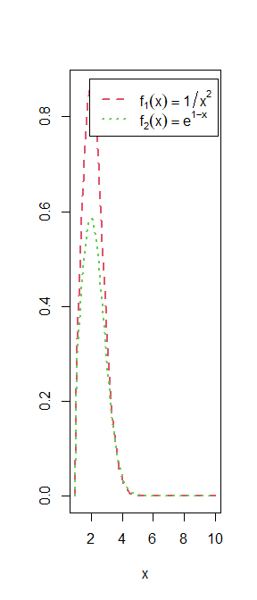

图3.1：g/f的函数图像

```r
g = function (x) {
  x ^ 2 / sqrt(2*pi) * exp(-x^2/2) * (x>1)
}

x <- seq(1, 10, 0.1)#取点
y_g <- g(x)#g(x)函数值
y_f1 <- 1 / x^2#f1函数值
y_f2 <- exp(1-x)#f2函数值

#绘制g/f的函数图像
ylim <- max(c(y_g/y_f1, y_g/y_f2))
gs <- c(expression(f[1](x)==1/x^2),
        expression(f[2](x)==e^{1-x}))
w <- 2
plot(x, y_g/y_f1, type = "l", ylab = "",
        ylim = c(0, ylim), lwd = w, lty = 2, col=2)
lines(x, y_g/y_f2, lty = 3, lwd = w,col=3)
legend("topright", legend = gs,
       lty = 2:3, lwd = w, inset = 0.02,col=2:3)
```

从图3.1可以看到，$\frac{g(x)}{f_2(x)}$函数值波动幅度较小，即更加接近于常数，所以利用$f_2(x)$的importance sampling所生成估计的方差将会更小。下面通过模拟计算进一步验证

```r
n <- 10000
theta.hat <- se <- numeric(2)#存储估计值theta.hat和标准差se
set.seed(513)

#importance function取f1，逆变换法
u <- runif(n)
x <- 1 / (1-u)
fg <- g(x) / (1/x^2)
theta.hat[1] <- mean(fg)
se[1] <- sd(fg)

#importance function取f2，逆变换法
u <- runif(n)
x <- 1-log(u)
fg <- g(x) / exp(1-x)
theta.hat[2] <- mean(fg)
se[2] <- sd(fg)

result <- cbind(theta.hat, se)
dimnames(result)[[1]] <- c("f1", "f2")
kable(result, caption = "表3.1：利用f1和f2的importance sampling所生成的估计和标准差对比")#kable绘制结果表格
```

表3.1：利用f1和f2的importance sampling所生成的估计和标准差对比

|  | theta.hat | se |
| --- | --- | --- |
| f1 | 0.4089707 | 0.3073441 |
| f2 | 0.3992673 | 0.1591873 |

从表3.1容易看到，两种方法估计结果theta.hat相近，但显然利用$f_2(x)$的importance sampling所生成估计的方差更小。

**5.14**

令$\theta=\int_{1}^{\infty} \frac{x^{2}}{\sqrt{2 \pi}} e^{-x^{2} / 2} d x$，$g(x)=\frac{x^{2}}{\sqrt{2 \pi}} e^{-x^{2} / 2}$。为利用importance sampling得到$\theta$的Monte Carlo估计，由题5.13中所述，这里选取较优的importance function
$$f(x)=e^{1-x}, \quad x>1$$
于是有
$$\theta=\int_{1}^{\infty} \frac{x^{2}}{e\sqrt{2 \pi}} e^{x-x^{2} / 2} f(x) d x$$
并且由逆变换法易得，该分布密度对应的随机变量可由$X=1-log(U)$，其中$U \sim U[0,1]$生成。则利用importance sampling进行估计的R代码如下所示

```r
n <- 10000
theta.hat <- se <- numeric(1)#存储估计值theta.hat和标准差se
set.seed(514)

#importance function取f，逆变换法
u <- runif(n)
x <- 1 - log(u)
fg <- g(x) / exp(1-x)
theta.hat[1] <- mean(fg)
se[1] <- sd(fg)

result <- cbind(theta.hat, se)
kable(result, caption = "表4.1：利用importance sampling所生成的MC估计和标准差")#kable绘制结果表格
```

表4.1：利用importance sampling所生成的MC估计和标准差

| theta.hat | se |
| --- | --- |
| 0.4019571 | 0.1574782 |

从表4.1可以看到，所求积分的importance sampling估计约为0.4。

## A-21003-2021-10-14

## Question

- Exercises 6.5 and 6.A (pages 180-181, Statistical Computing with R).
- If we obtain the powers for two methods under a particular simulation setting with 10,000 experiments: say, 0.651 for one method and 0.676 for another method. We want to know if the powers are different at 0.05 level.
- What is the corresponding hypothesis test problem?
- What test should we use? Z-test, two-sample t-test, paired-t test or McNemar test? Why?
- Please provide the least necessary information for hypothesis testing.

## Answer

### 6.5

容易知道均值的95%对称t置信区间由下式给出
$$[\bar{X}-\frac{S}{\sqrt{n}}t_{n-1}(0.975), \bar{X}+\frac{S}{\sqrt{n}}t_{n-1}(0.975)]$$
当样本来自$\chi^{2}(2)$时，下面利用Monte Carlo方法估计上述t置信区间的覆盖概率，每次模拟样本量$n=20$。R代码如下所示

```r
library(knitr)
set.seed(605)
calcCI <- function(n, alpha){
  x <- rchisq(n, 2)
  c1 <- mean(x) - sd(x)*qt(1-alpha/2, n-1)/sqrt(n)
  c2 <- mean(x) + sd(x)*qt(1-alpha/2, n-1)/sqrt(n)
  y <- as.integer(2>=c1 && 2<=c2)
  return(y)
}

n <- 20
alpha <- 0.05
m <- 5000
ys <- replicate(m, expr = calcCI(n, alpha))
kable(mean(ys), caption = "表1.1：样本来自chi^2(2)时t置信区间的覆盖概率")
```

表1.1：样本来自chi^2(2)时t置信区间的覆盖概率

| x |
| --- |
| 0.9204 |

可以看到当样本来自$\chi^{2}(2)$时，上述均值的t置信区间的覆盖概率约为92%，小于理论值95%。  
下面按照Example 6.4的方式，将来自$N(0,4)$的正态样本替换为来自$\chi^{2}(2)$的样本，计算此时方差置信区间的覆盖概率。

```r
set.seed(605)
n <- 20
alpha <- 0.05
m <- 5000
ys <- replicate(m, expr = {
  x <- rchisq(n, 2)
  c <- (n-1)*var(x) / qchisq(alpha, df=n-1)
  y <- as.integer(c>4)
  return(y)
})
kable(mean(ys), caption = "表1.2：样本来自chi^2(2)时方差置信区间的覆盖概率")
```

表1.2：样本来自chi^2(2)时方差置信区间的覆盖概率

| x |
| --- |
| 0.783 |

从表1.2可以看到，当样本来自$\chi^{2}(2)$时，Example 6.4方差置信区间的覆盖概率约为78%，与理论值95%差距甚远。进一步与上述t置信区间的覆盖概率（约92%）相比较，可以看到当样本偏离正态分布时，t置信区间比方差置信区间表现更加稳健。

### 6.A

下面利用Monte Carlo模拟，探究当样本偏离正态分布时，均值t检验的第I类错误概率是否与给定的显著性水平$\alpha$相等。检验问题为$H_{0}: \mu = \mu_{0}$ vs $H_{1}: \mu \neq \mu_{0}$

- (i)样本来自$\chi^{2}(1)$时

```r
set.seed(0)
n <- 20
alpha <- 0.05
mu0 <- 1

m <- 10000
ps <- replicate(m, expr = {
  x <- rchisq(n, mu0)
  ttest <- t.test(x, alternative = "two.sided", mu=mu0)
  p <- ttest$p.value
  return(p)
})

p.hat <- mean(ps < alpha)
kable(p.hat, caption = "表2.1：样本来自chi^2(1)时均值t检验的第I类错误概率")
```

表2.1：样本来自chi^2(1)时均值t检验的第I类错误概率

| x |
| --- |
| 0.1056 |

- (ii)样本来自$U[0,2]$时

```r
set.seed(0)
n <- 20
alpha <- 0.05
mu0 <- 1

m <- 10000
ps <- replicate(m, expr = {
  x <- runif(n, 0, 2)
  ttest <- t.test(x, alternative = "two.sided", mu=mu0)
  p <- ttest$p.value
  return(p)
})

p.hat <- mean(ps < alpha)
kable(p.hat, caption = "表2.2：样本来自U[0, 2]时均值t检验的第I类错误概率")
```

表2.2：样本来自U[0, 2]时均值t检验的第I类错误概率

| x |
| --- |
| 0.0507 |

- (iii)样本来自$\operatorname{Exp}(1)$时

```r
set.seed(0)
n <- 20
alpha <- 0.05
mu0 <- 1

m <- 10000
ps <- replicate(m, expr = {
  x <- rexp(n, 1)
  ttest <- t.test(x, alternative = "two.sided", mu=mu0)
  p <- ttest$p.value
  return(p)
})

p.hat <- mean(ps < alpha)
kable(p.hat, caption = "表2.3：样本来自Exp(1)时均值t检验的第I类错误概率")
```

表2.3：样本来自Exp(1)时均值t检验的第I类错误概率

| x |
| --- |
| 0.0803 |

从表2.1-2.3可以看到，(i)样本来自$\chi^{2}(1)$时，t检验的第I类错误概率约为0.1；(ii)样本来自$U[0,2]$时，t检验的第I类错误概率略大于0.05；(iii)样本来自$\operatorname{Exp}(1)$时，t检验的第I类错误概率约为0.08。因此整体来看，t检验在样本略微偏离正态分布时表现较为稳健；分情况对比来看，t检验在样本来自$U[0,2]$时表现最稳健，在样本来自$\operatorname{Exp}(1)$时表现次之，而在样本来自$\chi^{2}(1)$时与理论值0.05差距最大，表现较差。

### Question3

If we obtain the powers for two methods under a particular simulation setting with 10,000 experiments: say, 0.651 for one method and 0.676 for another method. We want to know if the powers are different at 0.05 level.

- What is the corresponding hypothesis test problem?

首先定义两种检验(Test1, Test2)的势分别为：

$\pi_1(\theta_0)$=P(给定参数$\theta=\theta_0$时Test1拒绝$H_0$),

$\pi_2(\theta_0)$=P(给定参数$\theta=\theta_0$时Test2拒绝$H_0$)

则对应的假设检验问题为：$H_{0}:\pi_{1}(\theta_0) = \pi_{2}(\theta_0)\longleftrightarrow H_{1}:\pi_{1}(\theta_0) \neq \pi_{2}(\theta_0)$，显著性水平$\alpha$取0.05。

- What test should we use? Z-test, two-sample t-test, paired-t test or McNemar test? Why?

由于10000次试验中所得到的数据为成对二分类数据（Test1/Test2是否拒绝了$H_0$），所以此处应该使用McNemar test。

- Please provide the least necessary information for hypothesis testing.

我们已经在此次模拟的10000次试验下得到了两种检验方法的势$\pi_1=0.651$，$\pi_2=0.676$。下面考虑每次试验中两种方法Test1, Test2得到的检验结果（是否拒绝了$H_0$），可以将其表示为如下所示的2x2列联表

```r
mat <- matrix(nrow = 3, ncol = 3)
mat[1,1:3] <- c("a","b","a + b")
mat[2,1:3] <- c("c","d","c + d")
mat[3,1:3] <- c("a + c","b + d","10000")
colnames(mat) <- c("Test2 reject","Test2 accpet","Row total")
rownames(mat) <- c("Test1 reject","Test1 accpet","Column total")
kable(mat)
```

|  | Test2 reject | Test2 accpet | Row total |
| --- | --- | --- | --- |
| Test1 reject | a | b | a + b |
| Test1 accpet | c | d | c + d |
| Column total | a + c | b + d | 10000 |

从模拟得到两种检验方法的势可知$a+b=6510, a+c=6760$，对于McNemar test，其检验统计量$\chi ^2 = \frac{(b-c)^2}{b+c}$在$H_0$成立的情况下近似服从$\chi ^2(1)$。因此为计算检验统计量$\chi ^2$，**我们还需要知道的最少信息为$a$的值，即共有多少次试验Test1和Test2同时拒绝了原假设$H_0$。**

最后若$\chi ^2>\chi ^2(0.95)$，则可认为两种检验方法的势在显著性水平0.05下是不同的。

## A-21003-2021-10-21

## Question

Exercises 6.C (pages 182, Statistical Computing with R).

## Answer

### 6.C

首先仿照**Example 6.8**，对Mardia多元偏度检验估计其第I类错误概率。由题知多元偏度统计量定义为
$$b_{1, d}=\frac{1}{n^{2}} \sum_{i, j=1}^{n}\left(\left(X_{i}-\bar{X}\right)^{T} \widehat{\Sigma}^{-1}\left(X_{j}-\bar{X}\right)\right)^{3}$$
且$nb_{1, d}/6$的渐近分布为$\chi^2(d(d+1)(d+2)/6)$，当$nb_{1, d}/6>\chi^2_{d(d+1)(d+2)/6}(1-\alpha)$时拒绝$H_0:\beta_{1, d}=0$。下面仿照Example 6.8，取显著性水平$\alpha=0.05$，样本容量$n=10, 20, 30, 50, 100, 500$。由于统计量渐近分布不依赖于样本的均值和方差，故样本可由标准多元正态分布$N_d(0, I_d)$生成，此处取维数$d=2$。则对Mardia多元偏度检验，估计第I类错误概率的R代码如下所示

```r
library(knitr)
library(MASS)

#计算多元偏度统计量的函数
mvsk <- function(x){
  xx <- scale(x, center=T, scale=F)#将样本矩阵x中心化
  n <- nrow(x)#获取样本量
  sk <- 1/n^2 * sum((xx %*% solve(cov(x)) %*% t(xx))^3)#检验统计量
  return(sk)
}

ns <- c(10, 20, 30, 50, 100, 500)#样本量
d <- 2#维数
alpha <- 0.05#显著性水平
cv <- qchisq(1-alpha, d*(d+1)*(d+2)/6)#检验临界值

p.reject <- numeric(length(ns))#存储第I类错误估计值
m <- 1e4#模拟次数
set.seed(99)
# for(i in 1:length(ns)){
#   mvsktests <- numeric(m)#存储每次试验的检验结果
#   for(j in 1:m){
#     x <- mvrnorm(ns[i], mu = rep(0, d), Sigma = diag(d))#生成n个多元正态分布样本，维数为2
#     mvsktests[j] <- as.integer(ns[i]*mvsk(x)/6 >= cv)#拒绝H0取1，否则取0
#   }
#   p.reject[i] <- mean(mvsktests)#拒绝H0的比例
# }
#
# #绘制结果表格
# result <- matrix(c(ns, p.reject), nrow = 2, ncol = length(ns), byrow = T)
# dimnames(result)[[1]] <- c("n", "Type I error rate")
# kable(result, caption = "表1：Mardia多元偏度检验第I类错误概率估计")
```

下面仿照**Example 6.10**，在受污染的多元正态总体（混合正态）下，模拟估计Mardia多元偏度检验的势。其中受污染的多元正态分布定义为
$$(1-\varepsilon) N_d\left(0, I_d\right)+\varepsilon N_d\left(0, 100I_d\right), \quad 0 \leq \varepsilon \leq 1$$
当$\varepsilon=0$或$\varepsilon=1$时该分布为多元正态分布，但$0 < \varepsilon < 1$时不是多元正态分布。我们可以取一列$\varepsilon$估计Mardia多元偏度检验的势，并绘制出相应的势曲线。类似于Example 6.10，此次模拟取显著性水平$\alpha=0.1$。多元偏度统计量的计算仍沿用函数`mvsk`。则估计Mardia多元偏度检验势的R代码如下所示

```r
alpha <- 0.1#显著性水平
n <- 500#样本量
m <- 2500#模拟次数
d <- 2#维数
epsilon <- c(seq(0, 0.15, 0.01), seq(0.15, 1, 0.05))#混合分布比例序列e
N <- length(epsilon)
pwr <- numeric(N)#存储每次模拟检验的势
cv <- qchisq(1-alpha, d*(d+1)*(d+2)/6)#检验临界值

set.seed(100)
# for(i in 1:N){ #对每个epsilon
#   mvsktests <- numeric(m)#存储每次试验结果，拒绝H0取1，否则取0
#   e <- epsilon[i]#混合分布比例e
#   for(j in 1:m){ #对每次试验
#     x1 <- mvrnorm(n, rep(0, d), diag(d))#生成多元正态样本N(0, I)
#     x2 <- mvrnorm(n, rep(0, d), 100*diag(d))#生成多元正态样本N(0, 100*I)
#     emat <- diag(as.integer(runif(n) <= e))#为生成混合分布构造系数矩阵，对角线元素以概率e取1，以概率1-e取0
#     x <- (diag(n)-emat) %*% x1 + emat %*% x2#生成混合分布样本，每行以概率1-e取N(0, I)，以概率e取N(0, 100*I)
#     mvsktests[j] <- as.integer(n*mvsk(x)/6 >= cv)#检验结果拒绝H0取1，否则取0
#   }
#   pwr[i] <- mean(mvsktests)#估计检验的势
# }
#
# #绘制power vs epsilon曲线
# plot(epsilon, pwr, type = "b",
#      xlab = bquote(epsilon), ylim = c(0,1))
# abline(h = alpha, lty = 3)
# se <- sqrt(pwr * (1-pwr) / m) #添加标准差
# lines(epsilon, pwr+se, lty = 3)
# lines(epsilon, pwr-se, lty = 3)
```

## A-21003-2021-10-28

## Question

Exercises 7.7, 7.8, 7.9 and 7.B (pages 213, Statistical Computing with R).

## Answer

### 7.7

根据题意,对数据集`scor`我们感兴趣的参数为
$$\theta=\frac{\lambda_{1}}{\sum_{j=1}^{5} \lambda_{j}}$$
其中$\lambda_{1}>\cdots>\lambda_{5}$为协方差矩阵$\Sigma$的特征值。下面计算$\theta$的样本估计$\hat{\theta}$，并利用bootstrap估计$\hat{\theta}$的偏差和标准差。

```r
library(knitr)
library(bootstrap)
library(boot)

Sigma <- cov(scor)#计算协方差矩阵的MLE
lambda_hat <- eigen(Sigma)$values#特征值
theta_hat <- lambda_hat[1]/sum(lambda_hat)#theta的样本估计

#计算theta bootstrap估计的函数，以传给boot的参数statistic
theta_i <- function(dat, inds){
  Sigma <- cov(dat[inds,])
  lambda <- eigen(Sigma)$values
  return(lambda[1]/sum(lambda))
}

set.seed(77)
obj_boot <- boot(data=scor, statistic=theta_i, R=200)#利用boot进行bootstrap抽样
theta_boot <- as.numeric(obj_boot$t)#bootstrap估计值
bias_boot <- mean(theta_boot) - theta_hat#bootstrap的偏差估计
se_boot <- sd(theta_boot)#bootstrap的标准差估计

#绘制结果表格
result <- matrix(c(theta_hat, bias_boot, se_boot), nrow = 1)
dimnames(result)[[2]] <- c("theta_hat", "bias_boot", "se_boot")
kable(result, caption = "表1.1：theta的样本估计和bootstrap的偏差和标准差估计结果")
```

表1.1：theta的样本估计和bootstrap的偏差和标准差估计结果

| theta_hat | bias_boot | se_boot |
| --- | --- | --- |
| 0.619115 | -0.00026 | 0.0461956 |

### 7.8

接题7.7，下面利用jackknife估计$\hat{\theta}$的偏差和标准差。

```r
Sigma <- cov(scor)#计算协方差矩阵的MLE
lambda_hat <- eigen(Sigma)$values#特征值
theta_hat <- lambda_hat[1]/sum(lambda_hat)#theta的样本估计

n <- nrow(scor)
theta_jack <- numeric(n)
for(i in 1:n){
  dat <- scor[-i,]
  Sigma <- cov(dat)
  lambda <- eigen(Sigma)$values
  theta_jack[i] <- lambda[1]/sum(lambda)
}
bias_jack <- (n-1)*(mean(theta_jack) - theta_hat)
se_jack <- (n-1)*sqrt(var(theta_jack)/n)

#绘制结果表格
result <- matrix(c(bias_jack, se_jack), nrow = 1)
dimnames(result)[[2]] <- c("bias_jack", "se_jack")
kable(result, caption = "表2.1：jackknife的偏差和标准差估计结果")
```

表2.1：jackknife的偏差和标准差估计结果

| bias_jack | se_jack |
| --- | --- |
| 0.0010691 | 0.0495523 |

### 7.9

接题7.7，下面利用`boot.ci`函数计算$\hat{\theta}$的95% percentile和BCa置信区间。

```r
set.seed(79)
obj_boot <- boot(data=scor, statistic=theta_i, R=2000)#利用boot函数进行bootstrap抽样
boot.ci(obj_boot, type = c("perc", "bca"))#利用boot.ci函数计算95% percentile和BCa置信区间
```

```
## BOOTSTRAP CONFIDENCE INTERVAL CALCULATIONS
## Based on 2000 bootstrap replicates
##
## CALL :
## boot.ci(boot.out = obj_boot, type = c("perc", "bca"))
##
## Intervals :
## Level     Percentile            BCa
## 95%   ( 0.5166,  0.7070 )   ( 0.5187,  0.7097 )
## Calculations and Intervals on Original Scale
```

从上述结果可以看到，percentile方法和BCa方法得到的95%置信区间非常接近，说明在本题情况下两种方法都较为稳健。

### 7.B

下面利用Monte Carlo模拟，对偏度分别估计(i)standard normal bootstrap置信区间，(ii)basic bootstrap置信区间，(iii)percentile置信区间的覆盖概率，并在上述置信区间不包含待估参数（偏度）时，分别统计待估参数位于上述三种置信区间左边（miss on the left）和右边（miss on the right）的比例。其中偏度定义为
$$\sqrt{\beta_{1}}=\frac{E\left[\left(X-\mu_{X}\right)\right]^{3}}{\sigma_{X}^{3}}$$
相应的样本偏度定义为
$$\sqrt{b_{1}}=\frac{\frac{1}{n} \sum_{i=1}^{n}\left(X_{i}-\bar{X}\right)^{3}}{\left(\frac{1}{n} \sum_{i=1}^{n}\left(X_{i}-\bar{X}\right)^{2}\right)^{3 / 2}}$$

- 样本来自正态总体$N(0,1)$时，可以计算其偏度为0

```r
#计算样本偏度
sk_i <- function(dat, inds){
  x <- dat[inds]
  xbar <- mean(x)
  m3 <- mean((x - xbar)^3)
  m2 <- mean((x - xbar)^2)
  sk <- m3 / m2^(3/2)
  return(sk)
}

alpha <- 0.05#显著性水平
n <- 200#样本量
m <- 5e3#MC模拟次数
sk <- 0#正态分布偏度系数
y <- matrix(nrow = m, ncol = 3)#存储CI是否覆盖参数
CI_miss <- matrix(nrow = m, ncol = 6)#存储CI位置，1-3列为参数是否落在3种CI左边，4-6列为参数是否落在3种CI右边

set.seed(0)
# for(i in 1:m){
#   x <- rnorm(n)#生成正态样本
#   obj_boot <- boot(data = x, statistic = sk_i, R=2000)#利用boot函数进行bootstrap抽样
#   obj_ci <- boot.ci(obj_boot, conf = 1-alpha, type = c("norm","basic", "perc"))#利用boot.ci函数计算95%置信区间
#   LCLs <- c(obj_ci[["normal"]][1,2], obj_ci[["basic"]][1,4], obj_ci[["percent"]][1,4])#置信区间下界
#   UCLs <- c(obj_ci[["normal"]][1,3], obj_ci[["basic"]][1,5], obj_ci[["percent"]][1,5])#置信区间上界
#   y[i,] <- as.integer(sk > LCLs & sk < UCLs)#CI是否覆盖参数
#   CI_miss[i,] <- as.integer(c(sk < LCLs, sk > UCLs))#CI位置，1-3列为参数是否落在3种CI左边，4-6列为参数是否落在3种CI右边
# }
#
# #绘制结果表格
# cp <- apply(y, 2, mean)
# cp <- matrix(cp, nrow = 1)
# dimnames(cp)[[2]] <- c("standard normal bootstrap", "basic bootstrap", "percentile")
# kable(cp, caption = "表4.1：三种bootstrap置信区间覆盖概率的MC估计（正态样本）")
#
# CI_left <- apply(CI_miss[,1:3], 2, mean)
# CI_right <- apply(CI_miss[,4:6], 2, mean)
# miss_prop <- rbind(CI_left, CI_right)
# dimnames(miss_prop)[[2]] <- c("standard normal bootstrap", "basic bootstrap", "percentile")
# kable(miss_prop, caption = "表4.2：偏度位于三种bootstrap置信区间左边/右边的比例（正态样本）")
```

- 样本来自卡方总体$\chi^2(5)$时，可以计算其偏度为$\sqrt{8/5}$

```r
n <- 200#样本量
m <- 5e3#MC模拟次数
sk <- sqrt(8/5)#卡方分布chi^2(5)偏度系数
y <- matrix(nrow = m, ncol = 3)#存储CI是否覆盖参数
CI_miss <- matrix(nrow = m, ncol = 6)#存储CI位置，1-3列为参数是否落在3种CI左边，4-6列为参数是否落在3种CI右边

set.seed(0)
# for(i in 1:m){
#   x <- rchisq(n, 5)#生成卡方样本
#   obj_boot <- boot(data = x, statistic = sk_i, R=2000)#利用boot函数进行bootstrap抽样
#   obj_ci <- boot.ci(obj_boot, conf = 1-alpha, type = c("norm","basic", "perc"))#利用boot.ci函数计算95%置信区间
#   LCLs <- c(obj_ci[["normal"]][1,2], obj_ci[["basic"]][1,4], obj_ci[["percent"]][1,4])#置信区间下界
#   UCLs <- c(obj_ci[["normal"]][1,3], obj_ci[["basic"]][1,5], obj_ci[["percent"]][1,5])#置信区间上界
#   y[i,] <- as.integer(sk > LCLs & sk < UCLs)#CI是否覆盖参数
#   CI_miss[i,] <- as.integer(c(sk < LCLs, sk > UCLs))#CI位置，1-3列为参数是否落在3种CI左边，4-6列为参数是否落在3种CI右边
# }
#
# #绘制结果表格
# cp <- apply(y, 2, mean)
# cp <- matrix(cp, nrow = 1)
# dimnames(cp)[[2]] <- c("standard normal bootstrap", "basic bootstrap", "percentile")
# kable(cp, caption = "表4.3：三种bootstrap置信区间覆盖概率的MC估计（卡方样本）")
#
# CI_left <- apply(CI_miss[,1:3], 2, mean)
# CI_right <- apply(CI_miss[,4:6], 2, mean)
# miss_prop <- rbind(CI_left, CI_right)
# dimnames(miss_prop)[[2]] <- c("standard normal bootstrap", "basic bootstrap", "percentile")
# kable(miss_prop, caption = "表4.4：偏度位于三种bootstrap置信区间左边/右边的比例（卡方样本）")
```

## A-21003-2021-11-04

## Question

Exercises 8.2 (pages 242, Statistical Computing with R).

Discussion：Design experiments for evaluating the performance of the NN, energy, and ball methods in various situations.